# Global Trends in Urban Cooling and Heating

Elliot Cohen, Henri Torbey, Michael Piccirilli, Yu Tian, Vijay Modi

May 20, 2015

```
Cohen, Elliot, Henri Torbey, Michael Piccirilli, Yu Tian and Vijay Modi (2015).
Global Trends in Urban Cooling and Heating. Working Paper of the Sustainable
Engineering Lab, Columbia University, Updated May 21 2015. Available online:
http://ecohen4.github.io/Energy/Global_Trends_v4.html
```

## Highlights

- Per-capita electricity consumption estimated for 36 global cities.
- Heating Demand, Cooling Demand and transition temperature between heating and cooling regimes empirically derived.
- Share of total electricity consumption for thermal comfort compared across cities.
- Timing and magnitude of peak demand for thermal comfort cooling estimated for all cities.
- Recent growth in cooling demand observed in emerging market cities.

## Abbreviations

- A/C, AC: Air Conditionning
- CDH: Cooling Degree Hours
- CI: Confidence Interval
- EIA: Energy Information Agency
- FERC: Federal Energy Regulatory Commission
- HDH: Heating Degree Hours
- HVAC: Heating, Ventilation and Air-condition
- IQR: Inter Quartile Range
- LDC: Load Duration Curves
- NCDC: National Climatic Data Center
- NOAA: National Oceanic and Atmospheric Administration
- TLC: Temperature-Load Curve
- Tt: Threshold Temperature
- T: Temperature

## Abstract

As the tropics and subtropics become increasingly urban, industrial and affluent, it is important to consider how energy demand – particularly for indoor thermal comfort – will evolve differently in these places than it has historically across the global North. Already, heating, ventilation and air conditioning (HVAC) account for 35% of total primary energy requirements of the United States (Kwok and Rajkovich 2010), and are expected to reach similar proportions in China within 5 years (Wan et. al. 2011). On a per capita basis, developed cities in the OECD (represented in our study by cities in the U.S. and Japan) require 35-90 W/°C (interquartile range) above a comfortable room temperature, while tropical/subtropical cities outside the OECD (mostly in South Asia, Africa and the Middle East) require 2-9 W/°C. The latter is expected to catch up to the former as household incomes rise and adoption of AC accelerates; and someday surpass the former, given higher indoor-outdoor summer temperature differentials.

## Motivation

Many of the world’s **largest** and **fastest-growing** cities–from Karachi (population 14 million; 34.6% populaiton increase from 2000-2010) to Delhi (22m; 39.4%), Dhaka (15m, 45.2%), Jakarta (10m; 14.8%), Bangkok (8m, 29.1%), Lagos (11m; 48.2%) and Kinshasa (9m, 55.4%)–are located in South Asia and Sub-Saharan Africa with tropical to sub-tropical climates unlike those of most OECD member cities in the global north. As the tropics/subtropics become increasingly urban, industrial and affluent, it is important to consider how energy demand – particularly for thermal comfort – will evolve differently in these places than it has historically across the OECD.

To illustrate the potential for vast differences in energy demand for thermal comfort between cities in the global north and cities in the tropics/subtropics, consider Delhi, India. With its massive population, extremely hot summer and hot-humid monsoon season, Delhi is unlike any city in the global north, but typical of South Asia: Peak summer temperatures routinely exceed 40 °C. (104 F.), and intense heatwaves can approach 50 °C. (122 F.). Given the huge temperature differential between outdoor (say 104 F.) and desired indoor air temperature (say 72 F.), and the thermodynamic fact that energy for cooling scales linearly with the temperature differential, cooling a room in Delhi will require twice as much energy as cooling the same room in New York where summer outdoor-indoor temperature differentials are typically half that.

In addition to higher temperatures, the cooling season is also much longer: in the past year, Delhi had nearly **six** times as many cooling-degree days as New York City (again assuming a desired indoor air temperature of 72 °F). Compounded by (a) leaky building envelopes in developing world cities (designed for natural ventilation, not air conditioning), (b) intense heat-island effects (typically less green space), and (c) massive population growth – peak electricity demand in emerging megacities could one day surpass that of their neighbors to the north – not only in aggregate terms because of their population, but also *per-capita* due to climate, building design and thermodynamics.

Already, heating, ventilation and air conditioning (HVAC) account for 35% of total primary energy requirements of the United States (Kwok and Rajkovich 2010). In China, buildings accounted for 24.1% of total energy consumption in 1996, 27.5% by 2001, and a projected 35% by 2020 (Wan et. al. 2011). Globally, buildings consumed 40% of total primary energy in 2012 (IEA 2015), equivalent to the chemical energy stored in 5348 million tonnes of oil; or the wattage output of 50 billion humans working at peak exertion.

At the city-scale, we expect HVAC to play an even larger role in driving total final energy consumption as compared to national and global averages due to higher population density, heat-island effect, and tendency towards service-economy, which increases the share of air-conditioned commercial real-estate. Researchers in China suggest that large commercial buildings with full A/C require 10-20 times more energy per-square foot compared to residential buildings (Wan et. al. 2011, Xu et. al. 2013). Given this confluence of events, our goal is to quantify the manitude and timing of peak demand for heating and cooling in rapidly developing cities.

Given our interest in tropical-subtropical cities where heating requirements are minimal to non-existant, we focus on electrical final energy, and do not consider heating fuels. This decision is supported by the fact that subtropical cities with mild heating requirements tend to adopt plug-in electrical space heaters anyway, rather than capital-intensive fuel heating as is common in the U.S., or district steam heating as is common in parts of Europe and Northern China.

Finally, we are intersted in the effect of heating/cooling on peak-load management from a utility-perspective. To that end, we have collected hourly electricity demand timeseries from 40 electric utilities serving cities or urban agglomerations throughout the world. Roughly half of the cities are located in OECD-member countries, and half in non-OECD nations.

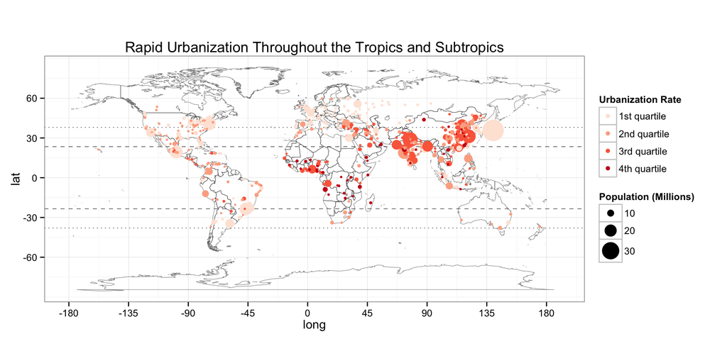

*Figure 1: UN World Urbanization Prospects 2014*

### Global Energy Service Provision Parity

Urbanization, rising incomes, and the income elasticity of energy services in emerging economies will largely determine the trajectory of global energy demand (and associated environmental impacts) over the coming decades (Chaturvedi et. al 2014). As incomes rise, energy demand increases along the extensive margin as more households and businesses purchase energy-consuming assets for the first time (Gertler et al. 2013). As populations rise, energy demand increases further along the extensive margin as the total number of households and businesses increases as well, producing a multiplicative effect (Commoner 1972).

Along the intensive margin, households and businesses tend to trade-up the energy-intensity ladder: transitioning from fans to window-unit A/C to centralized A/C, from clothesline to spin-dryer to heated-dryer, from two-wheeler to compact car to SUV. Energy intensity may eventually come back down due to efficiency gains, but the process of turning over accumulated capital stock is very long and slow.

The current trajectory of economic development in emerging-market cities is towards eventual parity with the OECD (Chaturvedi et. al. 2014). Likewise, energy demand will also tend towards parity with the OECD, but in terms of *service provision*, and not simply BTU or kWh. Households and businesses do not demand energy *per-se*, but energy services such as thermal comfort (cooling, dehumidification and heating), food storage (refrigeration), food preparation (cooking, boiling, microwaving), cleaning (washing, drying), work productivity (mobile phones and computers), communication (mobile phones and computers), and entertainment (TV, mobile phones and computers). Thus, to even begin to accurately project future energy demand, we must start with a baseline assessment of current demand for energy services.

This study aims to address that prerequisite by quantifying current demand for thermal comfort in major emerging market cities, and providing benchmark comparison with mature urban economies in the U.S. and Japan. We focus on thermal comfort as compared to other end-use energy services because it is by far the largest driver of peak electrical demand in the residential and commercial sectors (Segal et al. 1992; Crowley et al. 2003; McNeil and Letschert 2007), which in turn dominate the energy footprint of population-dense cities (Kennedy et. al. 2010).

### Drivers of Urban Electricity Demand

In developed cities, building energy use accounts for roughly half of all greenhouse gas emissions attributable to that city (review of eight cities in the U.S. by Hillman and Ramaswami 2009). Specifically, electricity and heating fuel use in buildings generate (on average) as much GHG emissions as all surface transportation, airline travel, upstream fuel processing, food production, cement manufacturing, potable water/wastewater treatment and long-distance freight, combined (e.g. the flow of essential goods and services into and within cities; Hillman and Ramaswami 2009). Of the roughly 50% of urban GHG emissions attributable to building energy use, roughly half of that (depending on climate and prevailing architectural design) comes from electricity, with the other half coming from heating and industrial fuels on a life-cycle basis (review of ten international cities by Kennedy et. al. 2010).

In developing cities, buildings account for a slightly smaller share of city-wide GHG emissions, estimated at 43% for a case study of Delhi, India, using the same system boundaries and methodology as for the aforementioned U.S. cities (Chavez et. al. 2012).

#### Integrated Assessment Models

Eom et. al. (2012) identify five structural variables that drive long-term building energy use: (1) population growth, (2) economic growth, (3) urbanization, (4) per-capita floor space, and (5) demand for building energy services. This formulation is supported by Chatturvedi et. al. (2014), van Ruijven et. al. (2011), and serves as the foundation for a building energy sub-routine of the Global Change Assessment Model (GCAM), first developed by Edmonds and Reily (1983), and used widely in a long-lineage of studies since.

GCAM belongs to a class of models known as integrated assessment models, which approximate a web of interactions between endogenous variables given exogenous boundary conditions (Edmonds and Reily 1983). Integrated assessment models such as GCAM are well-suited to high-level, economy-wide scenario analysis (see Wigley and Raper 1992; 2002, for two excellent examples among many).

#### Physical Models

On the other end of the [urban energy modeling] spectrum are physical models that require detailed climatological, meteorological and building inventory data. Physical models are well-suited to answer specific inquiries regarding near-term energy use at high resolution. They do not attempt to model interactions with the broader economy. There are literally hundreds of such models in the literature, covering a wide range of building typologies and climate zones, and therefore, we only attempt a cursory catalog of salient examples.

Building energy demand for thermal comfort (in particular) has been evaluated for many regions of the world: China (Wan et. al. 2010; Eom et. al. 2012); Hong Kong (Lam et. al. 2010); Malaysia (Saidur 2009); Jordan (Shariah et. al. 2009); Turkey (Eskin and Türkmen 2008); Europe (Bluysen et. al. 2011) and multiple regions (Lam et. al. 2010).

There have also been a large number of studies looking at the effect of climate change on heating/cooling demand in buildings: Australia (Wang et al 2010); Burkina Faso (Ouerdrago 2012); Switzerland (Frank 2011); Honk Kong (Lam et. al. 2010); UAE (Radhi 2009); Tehran (Delfani et al 2010); Germany (Olonscheck et al 2011); Multiple regions (Wan et al 2010); Subtropics (Wong et al 2010); two global outlooks (Wan et al 2009; Isaac and van Vuuren 2009) and two review articles (Yao and Hasbi 2013; Li 2012).

Physical models are the gold-standard for simulating energy demand in a specific building or class of buildings. However, our study takes an urban-metabolism approach in which the behavior of the entire city is of interest. Few cities in the world publish full building-stock inventories (including residential, commercial, industrial, government and public buildings such as hospitals, libraries and schools) sufficient to reasonably estimate total urban energy demand from the bottom-up. For this reason, we opt for a statistical approach (described next) using high-resolution electric utility data.

#### Statistical Models

A third class of urban energy demand models are statistical; including regression, pure time-series, and mixed-method econometric models. We describe time-series and econometric models briefly for context, and then introduce regression techniques, which serve as the basis for our approach.

##### Time-Series and Econometric Models

Rallapalli and Ghosh (2012) apply a non-stationary time-series model to accurately predict energy demand in all 5 regional power grids of India. Their model out-performs official forecasts of the Central Electricity Authority of India for both in-sample and out-of-sample prediction.

Jung (1993), Fillipini (1999), Tiwali (2000), Fillipini and Pachauri (2004) and World Bank (2008) apply econometric approaches to estimate the income elasticity of electricity demand in Korea, Switzerland, India, India and India, respectively.

Econometric approaches can be catalogued into macro- and micro-level approaches. Macroeconomic approaches employ top-down, national/sub-national summary statistics (e.g. Bose and Shukla 1999; Chaturpuri et a. 2014), whereas microeconomic approaches use bottom-up household survey data to analyze across different heterogeneous sub-groups (e.g. Tiwari 2000; Pachauri 2004; The World Bank 2008).

##### Regression Models

Diurnal and seasonal variability in urban electricity demand is driven, in large part, by human response to meteorological factors (Segal et al.,1992; Thatcher, 2007).

Segal et al. (1992) evaluated the relationship between summer peak energy demand in Israel and a host of meteorological parameters. Segal demonstrated that a simple linear model with just a few predictors, namely temperature and humidity, performs as well as more complex models with many additional predictors.

Thatcher (2007) built a complex demand forecast model with over 50 model parameters, but ultimately only require daily max/min temperature and relative humidity as input to estimate electricity demand. Thatcher’s model takes daily max/min temperatures to estimate apparent temperature in 30-minute intervals using sine-exponential technique; then applies a modified linear regression model to predict electricity demand. The model is also applied to estimate how Load Duration Curves (LDC) change as a result of a one degree increase in the average temperature in Australian state capital cities.

Wan et. al. (2011) estimate baseline and future heating and cooling demand for a generic air-conditioned office building in five Chinese cities representing five distinct climate zones. Their study introduces a clever approach for extracting orthogonal (non-redundant) information from co-linear meteorological data (dry bulb temperature, wet bulb temperature and solar radiation) via Principal Component Analysis, and then applies the first principal component in a regression framework to estimate building heating and cooling loads. Results are benchmarked to a physical-based building energy model as proof-of-concept, with impressive results.

Our analysis draws upon consensus findings from the literature (e.g. electricity demand in urban areas is largely a function of temperature) to build our own streamlined urban electricity demand model. The purpose of our model is not precise prediction (we leave that to the electric utilities themselves), but rather a generalized framework that can be applied across multiple, data-sparse cities simultaneously with reasonable accuracy.

##### Special Considerations in Tropical and Sub-Tropical Cities

Pachauri and Spreng (2004) found that urban households in India change their energy consumption patterns with rising incomes. Households consume more energy per capita and move from less clean-burning energy sources such as biomass and kerosene to higher quality energy sources such as electricity and LPG. Both trends points towards higher peak electricity demand and higher integral energy consumption.

Two excellent studies by the same author (Gupta 2012, 2014) provide insights into the effect of temperature on thermal-comfort seeking behavior in emerging economies. The first, Gupta (2012) adopted a semi-parametric coefficient model that allowed the temperature-electricity relation to vary over time for Delhi. His main findings were that electricity demand is a U-shaped function of temperature and that the cooling demand per unit increase in temperature (MW/°C) is increasing over time. Gupta (2014) applies a similar analysis to 28 Indian states, rather than a single city.

Gupta found summer electricity demand temperature sensitivity is higher in hotter Indian states and conversely, winter electricity demand temperature sensitivity is higher in colder Indian states. He hypothesized that in hotter climates, people have more cooling equipment, and similarly, in colder states people have more heating equipment. He also conjectured that the effect of both hotter and colder weather on electricity demand sensitivity would be more pronounced with higher incomes and GDP/Capita.

This study builds on the work of Gupta (2014) by conducting a global survey of electrical heating and cooling demand, including emerging and developed cities in the US, India, West Africa, and South Asia.

The magnitude, timing, ramp-rate and ability to load-shift peak electrical demand will have huge implications on electricity grid planning – including capacity expansion, technology deployment, capital costs, operating costs, consumer prices, supply reliability and environmental impact. More broadly, it will have implications on the global transition to renewable energy given the limitations of meeting large and ‘peaky’ demand (attributable to thermal comfort seeking behavior) with non-dispatchable resources such as wind and solar.

## Objectives

Energy demand projections abound, but are often saddled with excessive complexity (Bhattacharyya and Timilsina 2009). Complexity translates to proliferation of estimated model parameters, which in turn compounds uncertainty, limits degrees of freedom, diminishes generalizability and obfuscates interpretability.

A review of multi-decadal energy demand forecasts for the U.S. economy were found to be consistently off the mark (Craig et al. 2002). Forecasts by the U.S. Department of Energy for 1975 to 2000 overestimated demand by up to a factor of 2. In fact, of a dozen independent energy forecasts evaluated, only one (Lovins 1979) proved accurate. “A perception that a complex model with extensive input data produces more accurate results might not be always true” (Bhattacharyya and Timilsina 2009, pg 8). The importance of parsimony in energy modeling cannot be overstated (Armstrong, 2001).

To side-step many of these pitfalls, we propose a well-defined, theory-driven and empirically-supported iterative regression model for estimating urban electricity demand.

The objective of this study is to answer four key research questions:

1. What is the current level of electricity demand for heating and cooling services in major emerging cities, as measured by MW/°C above a known threshold temperature?
2. What is the magnitude of seasonal energy consumption for heating and cooling in major emerging cities, as measured by total GWh?
3. How do per-capita heating and cooling demand compare across cities, as measured by W/(°C x capita)?
4. How does the share of annual energy consumption used for heating and cooling compare across cities, as measured by a fraction of the total?

## Data

At present, there is scant baseline information publically-available on urban electricity demand for a cross-section of global cities. This article aims to fill that gap. In addition to the tables, figures and analysis reported here, all of the underlying data is curated and made freely available (with citation) on [github](https://github.com/Ecohen4/Energy). We encourage fellow researchers to [fork](https://help.github.com/articles/fork-a-repo/) the repository and contribute new data via [pull request](https://help.github.com/articles/using-pull-requests/).

The starting point for identifying major emerging cities was the UN World Urbanization Prospects (2014), subset to the 100 fastest growing cities with more than 2M inhabitants. For comparison, data for US cities was collected from the Federal Energy Regulatory Commission and the US Energy Information Administration.

*Table 1: Data sources summary table*

| City | Country | Load | Weather | Population |
| --- | --- | --- | --- | --- |
| Abidjan | Cote d’Ivoire | 2010-2013 (a) | 2010-2013 (m) | 1990-2030 (n) |
| Accra | Ghana | 2013-2014 (b) | 2010-2013 (m) | 1990-2030 (n) |
| Amman | Jordan | 2011-2014 (c) | 2010-2013 (m) | 1990-2030 (n) |
| Antigua | Antigua and Barbuda | 2011-2011 (d) | 2010-2013 (m) | - |
| Beirut | Lebanon | 2011-2014 (e) | 2010-2013 (m) | 1990-2030 (n) |
| Chandigarh | India | 2011-2013 (d) | 2010-2013 (m) | 1990-2030 (n) |
| Chattanooga | U.S. | 2006-2013 (s) | 2006-2013 (m) | 2006-2013 (t) |
| Colorado Springs | U.S. | 2006-2013 (s) | 2006-2013 (m) | 2006-2013 (t) |
| Dakar | Senegal | 2011-2014 (f) | 2010-2013 (m) | 1990-2030 (n) |
| Delhi | India | 2012-2013 (e) | 2010-2013 (m) | 1990-2030 (n) |
| Detroit | U.S. | 2006-2008 (s) | 2006-2008 (m) | 2006-2008 (t) |
| El Paso | U.S. | 2006-2013 (s) | 2006-2013 (m) | 2006-2013 (t) |
| Eugene | U.S. | 2006-2013 (s) | 2006-2013 (m) | 2006-2013 (t) |
| Honolulu | U.S. | 2006-2013 (s) | 2006-2013 (m) | 2006-2013 (t) |
| Inidanapolis | U.S. | 2006-2008 (s) | 2006-2008 (m) | 2006-2008 (t) |
| Kano | Nigeria | 2014 (d) | 2014 (m) | 1990-2030 (n) |
| Kupang | Indonesia | 2013 (d) | 2013 (m) | 2011 (p) |
| Los Angeles | U.S. | 2006-2013 (s) | 2006-2013 (m) | 2006-2013 (t) |
| Manila City | Philippine | 2011-2013 (g) | 2010-2013 (m) | 2010-2015 (o) |
| Mbabane | Swaziland | 2012-2014 (h) | 2010-2013 (m) | 2010 (p) |
| Nairobi | Kenya | 2011-2013 (i) | 2010-2013 (m) | 1990-2030 (n) |
| New York City | U.S. | 2007-2012 (d) | 2007-2012 (m) | 2007-2012 (q) |
| North Little Rock | U.S. | 2010-2013 (s) | 2010-2013 (m) | 2010-2013 (t) |
| Omaha | U.S. | 2006-2013 (s) | 2006-2013 (m) | 2006-2013 (t) |
| Philadelphia | U.S. | 2009-2011 (r) | 2009-2011 (m) | 1990-2030 (n) |
| Sacramento | U.S. | 2006-2013 (s) | 2006-2013 (m) | 2006-2013 (t) |
| San Diego | U.S. | 2012-2013 (s) | 2012-2013 (m) | 2012-2013 (t) |
| Singapore | Singapore | 2013-2013 (j) | 2010-2013 (m) | 1990-2030 (n) |
| Springfield | U.S. | 2011-2013 (s) | 2011-2013 (m) | 2011-2013 (t) |
| Tacoma | U.S. | 2006-2013 (s) | 2006-2013 (m) | 2006-2013 (t) |
| Tema | Ghana | 2014 (b) | 2014 (m) | 2013 (v) |
| Tokyo | Japan | 2008-2014 (k) | 2010-2013 (m) | 2008-2014 (u) |

(a): Autorite Nationale de Regulation du Secteur de l’Electricite (b): Ghana Grid Company (c): National Electric Power Company (d): Sustainable Engineering Lab (e): Electricite Du Liban (f): Senelec (g): Philipine Electricity Market Corporation (h): Swaziland Electricity Company (i): Kenya Power and Lighting Company (j): Energy Market Authority (k): Tokyo Electric Power Company (l): FERC & EIA (m): National Oceanic and Atmospheric Administration (n): United Nations World Urbanization Porspects - 2014 (o): National Statistical Coordination Board - Philippine Statistics Authority (p): UN Data (q): US Census Bureau (r): PJM (s): Federal Electricity Regulatory Commission - form 714 (FERC) (t): Energy Information Administration - form 826 (EIA) (u): Email correspondence with Tokyo Electric Power Company (TEPCO) (v): Wikipedia

#### Weather Data

High-resolution weather data are indispensable to accurate energy demand forecasts (Segal et al. 1992; Sailor 2001; Crowley et al. 2003; Thatcher 2007). Fortunately, national weather services and climate information centers such as the U.S. National Oceanic and Atmospheric Administration (NOAA), Britain’s Met Office, and India’s Institute for Tropical Meteorology (IITM), collect, curate, analyze and publish meteorological data from thousands of weather stations worldwide.

NOAA offers a wealth of meteorological information through the NCDC data portal. The data is available on the [Online Climate Data Directory](http://www.ncdc.noaa.gov/cdo-web/) website. It is also available via FTP, which is more efficient for batch queries, and is the method used here.

However, handling large meteorological datasets can be unwieldy to the uninitiated. To address this issue and make meteorological data more accessible to a wider range of scientists, engineers and practitioners, we developed the `weatheR` library for the statistical computing language R. The `WeatheR` library dramatically simplifies, streamlines and improves the reproducability of our current work. Complete methodological details, step-by-step instructions and example vignettes are available on our [github page](http://ecohen4.github.io/Cohen-McCreight/weatheR.html).

Briefly, weather data was collected as follows:

- Cities of interest are geo-referenced via the Google Maps API.
- City coordinates are passed into a nearest-neighbor search algorithm to the find the k-nearest active weather stations.
- “Best” neighbor is selected from the k-nearest neighbors using multi-objective criteria of geographic proximity and completeness of the meteorological record.
- “Best” meteorological record is chosen, subset, scrubbed and interpolated to yield hourly temperature and humidity observations for each city and period of interest.

Applying the functions of the weatheR library to the cities and years for which load data was collected, hourly temperature time-series were obtained. The below boxplot shows the temperature distributions for these cities.

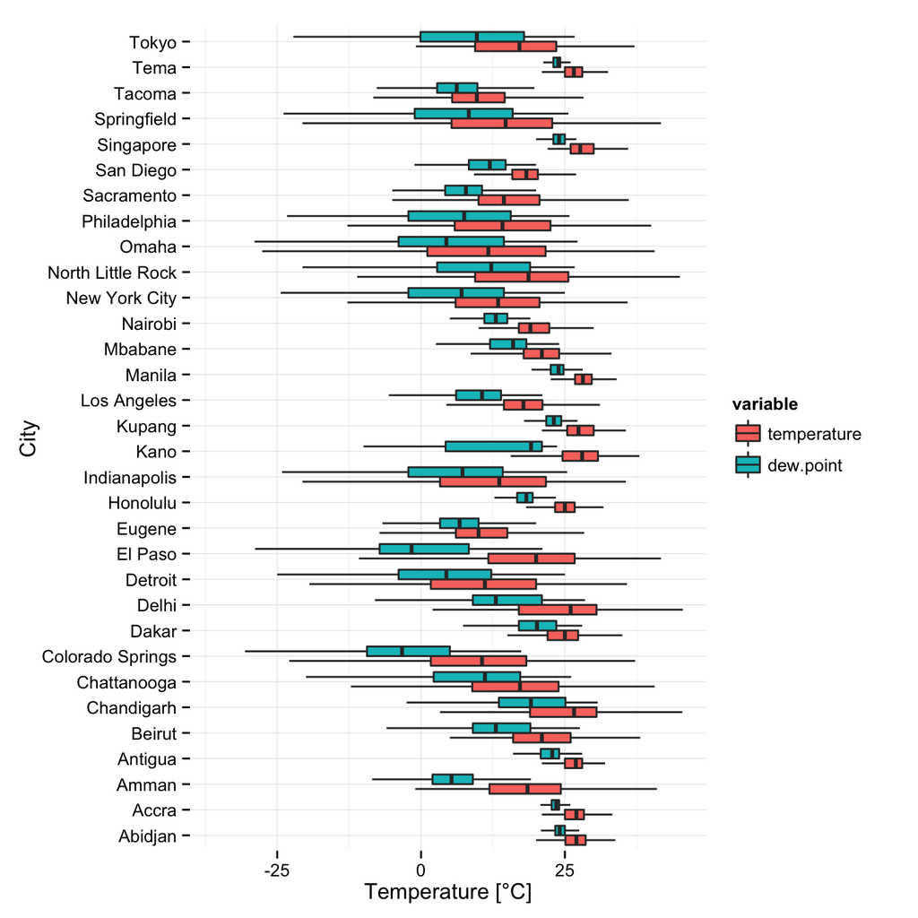

#### Demand Data

Hourly electricity demand data was collected from utility companies, system operators and electricity regulatory bodies serving the cities of interest. Data was collected for the past 3 years, if possible.

Data for Beirut, Lebanon and Amman, Jordan were estimated from national data. The Jordanian utility NEPCO provided monthly ratios of energy consumption for Amman compared to Jordan as a whole. The ratio was approximately 50% for all the months. Amman is the only major city in Jordan.

Data for Abidjan, Ivory Coast and Dakar, Senegal were estimated from country level loads by the utilities themselves: Monthly ratios of peaks at city-level feeders to peaks at grid-level were applied.

Data for Philadelphia includes the surrounding areas and not only the city itsels, as opposed to the data for New York City.

Data for Manila includes the whole Luzon islands.

#### Population Data

Population data was collected from many sources as per the summary table at the top of the *Data* section. They are used to normalize energy demand and consumption to a per capita level as per the *Methods* section.

The population data collected for some U.S. cities from EIA were in the form of “residential customer count”. They were therefore multiplied by the U.S. average number of persons per household (estimated to be 2.63 by the U.S. Census Bureau) to obtain a population service count.

For these cities, the collected load data from FERC were related to the corresponding EIA customer count by merging the FERC 714 form with the EIA 826 form. The following table illustrates this:

*Table 2: US Utilities data sources*

|  | City | Utlity Name | EIA Code | FERC Respondent ID |
| --- | --- | --- | --- | --- |
| 1 | Chattanooga | Electric Power Board of Chattanooga | 3408 | 162 |
| 2 | North Little Rock | North Little Rock | 13718 | 156 |
| 3 | Colorado Springs | Colorado Springs Utilities | 3989 | 143 |
| 4 | Detroit | Detroit Edison Company | 5109 | 152 |
| 5 | El Paso | El Paso Electric Company | 5701 | 160 |
| 6 | Eugene | Eugene Water & Electric Board | 6022 | 166 |
| 7 | Honolulu | Hawaiian Electric Company, Inc | 19547 | 178 |
| 8 | Indianapolis | Indianapolis Power & Light Company | 9273 | 184 |
| 10 | Los Angeles | Los Angeles Department of Water and Power | 11208 | 194 |
| 11 | Omaha | Omaha Public Power District | 14127 | 223 |
| 12 | Sacramento | Sacramento Municipal Utility District | 16534 | 243 |
| 13 | San Diego | San Diego Gas & Electric Company | 16609 | 246 |
| 14 | Springfield | City Utilities of Springfield, MO | 17833 | 141 |
| 15 | Tacoma | City of Tacoma, Dept. of Public Utilities | 18429 | 139 |

Note: EIA reports customer count for City of North Little Rock for the year 2014 only. This number was thus assumed to be the same for the years 2010 to 2013.

Tema (Ghana) population was only found for the year 2013. We therefore assumed it stayed constant in the year 2014.

## Methods

Two main analyses are performed on the set of city-year data, described above. The first one consists of estimating the sensitivity of the daily peak demand of electricity to ambient temperature, and the second consists of estimating the amount of energy consumed for thermal-comfort seeking (cooling and heating). The below sections detail the key concepts and methodology used to obtain these estimations.

### Cooling/Heating Degree Hours (CDH/HDH)

For every city/year combination, Cooling Degree Hours is defined as the sum at every hour of the difference between the recorded temperature and a certain ‘comfortable’ temperature at which no cooling nor heating is required. If this difference is negative, it is taken as 0, as per the below formula:

${(1) CDH} = \sum_{hour=1}^{8760} max\left \{ T_{observed,hour} - T_{threshold}, 0 \right \}$

In a similar way, Heating Degree Hours is defined as the sum at every hour of the difference between a certain ‘comfortable’ temperature and the observed temperature at that hour. If this difference is negative, it is taken as 0:

${(2) HDH} = \sum_{hour=1}^{8760} max\left \{ T_{threshold} - T_{observed,hour}, 0 \right \}$

In other words, CDH and HDH represent the number of degrees per year that require respectively cooling and heating to reach the degree of thermal-comfort set by the ‘comfortable’ temperate. This temperature is usually set at 20 °C, however the subsequent sections will derive a threshold temperature that is specific for the city-year considered.

### Temperature-Load Curve (TLC) & Threshold Temperature (Tt)

Starting with the pairwise observations of hourly temperature and energy demand (MW) the temperature-load profile of every city-year-hr combination can be obtained. Each year is evaluated separately to estimate change over time, ceteris-paribus. Each hour of the day (1-24) is evaluated separately to control for natural diurnal rhythms, that is, demand will tend to be higher at 7pm than 3am, irrespective of the weather. Separate city-year-hr models also allows for checking the stability of results across multiple models.

Iterative testing has shown that to obtain a solid profile suitable for a regression fit, temperature-load data must be available for at least the equivalent of 3 months to capture a wide range of temperatures. Therefore, all the collected data were filtered to this criteria and a small number of city-year combinations were omitted as a consequence.

Economic activity is typically lower on weekends compared to weekdays, and electricity demand is commensurately lower. To remove this noise, which is unrelated to temperature, weekends were omitted.

By contrast, cities in the tropics and sub-tropics tend to have cooling but no significant heating. For example, Dakar Senegal (latitude = 14.7°) has a distinct cooling seasons as can be seen from the TLC (figure 3).

A third category is cities located in temperate climates with little to no cooling and heating infrastructure and thus no strong relationship between temperature and load. The TLC for these cities will lack a definite Threshold Temperature and the slope of the regression will not be significantly different than zero. As we will see in the result section, several cities have very recently transitioned from non-significant to significant Heating & Cooling, which indicates increased penetration of thermal-comfort appliances (see figures 5).

### Cooling/Heating Power Demand

This section aims to quantify the TLC for a set of global cities. Cities are divided in two groups: Heating *&* Cooling, and Heating *or* Cooling. For cities for heating or cooling only, a sample linear regression is used to model load as a function of temperature. For cities with heating and cooling, a segmented linear regression is performed where in two linear models (one for cooling, one for heating) are iteratively estimated to minimize the total sum of square root errors. The intercept (Beta0) and Beta coefficients (Beta1) for the two linear models are estimated simultaneously by ordinary least squares given an initial condition of the breakpoint between the two linear regressions. In physical terms, the breakpoint is the threshold temperature (or transition temperature) between heating and cooling seasons. For each city, the initial condition was set equal to the mean temperature observed in that city. Since a large number of city-year combinations are considered in this study, we developed R functions to automate the process. For every city-year combination, the first step of the algorithm is to compute the IQR (difference between the 75th percentile and the 25th percentile) of the temperature distribution. Empirically, we found that for cities with distinct heating and cooling seasons the IQR was higher than 6.8 and that cities with heating or cooling have a temperature IQR less than 6.8.

Figure 3 (below) shows the resulting linear regression fit for NYC and Dakar respectively. The coefficients (Heating and/or Cooling), their significance and the x-coordinate of the break-point (threshold temperature) are extracted and saved for every city at every year. This is done for all cities at daily peak load observations.

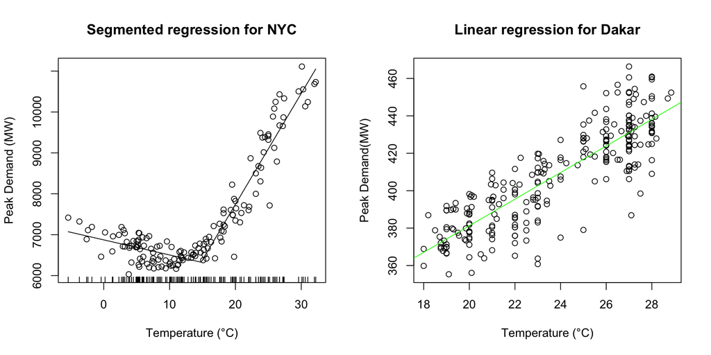

*Figure 3: TLCs and regression models for New York City and Dakar, 2012*

This process is repeated for every hour of the day for each city-year combination, that is, fit a linear/segmented regression model to all the weekday/weekend midnight, 1ams, 2ams, etc. resulting in 24 TLCs for each city-year combination. This will be used in the next section to estimate integral energy consumption for heating and cooling.

To illustrate this, we show the TLC (figure 4) for New York City in 2012 at midnight, 6am, 12pm and 6pm. Note the change in slope in cooling and heating demand depending on time of day.

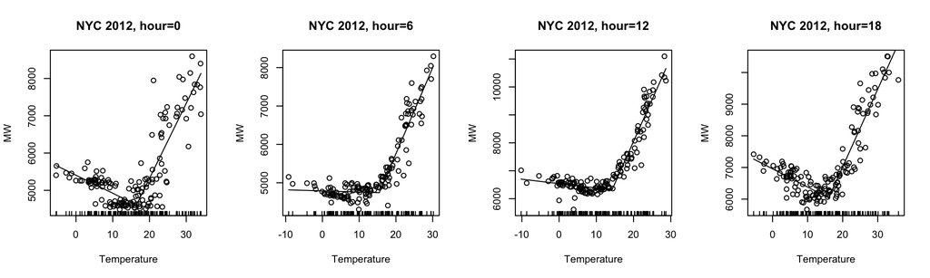

*Figure 4: TLCs and regression models for New York City 2012 at midnight, 6am, 12pm and 6pm*

The coefficients (heating and/or cooling) obtained at every hour for every city-year combination are a measure of demand for thermal-comfort seeking, that is how much power is required to keep residents in city comfortable. Coefficients are expressed in MW/°C and therefore represent the incremental change in load for every 1°C change in threshold temperatures. In subsequent sections, the Cooling Coefficient will be referred to as the Cooling Demand and the Heating Coefficient as the Heating Demand.

### Integral Energy Consumption for Heating and Cooling

After estimating the characteristic energy demand for cooling and heating at each hour of the day (0-23) for each year from the TLC, we can reconstruct integral energy consumption for thermal-comfort by multiplying energy demand per °C by the degree hours (equations 1 and 2). Before computing integral energy consumption, a data filter was applied to select city-year combinations containing the equivalent of at least 350 days of hourly observations. 350 days was chosen instead of 365 days to allow a modest tolerance for missing data (a maximum of 2 weeks of equivalent hourly observations).

${(3) Cooling Energy_{city,yr}} = \sum_{hour=1}^{8760} max\left \{ Cooling Demand_{city,yr,hr}*(T_{observed,city,yr,hr} - T_{threshold,city,yr,hr}), 0 \right \}$

${(4) Heating Energy_{city,yr}} = \sum_{hour=1}^{8760} max\left \{ Heating Demand_{city,yr,hr}*(T_{threshold,city,yr,hr}-T_{observed,city,yr,hr}), 0 \right \}$

Two important points must be noted concerning the above two equations. First,for any city-year-hour combination, if the Cooling Demand or Heating Demand is not significant at the 90% confidence interval, it is set to 0. Second, for cities with only heating or cooling, or no relationship at all, the threshold temperature is taken as the 5th percentile of the temperature distribution to avoid outliers.

## Results

The following section presents results and discussion for each of four stated research objectives. Taken together, our results represent the first comparative analysis of electrical heating and cooling demand at the city-scale, including both OECD and non-OECD member cities.

### Cooling

A significant cooling signal was detected (90% confidence level) for 34 of 36 cities analyzed. The only cities without a clear cooling signal were Mbabane, Swaziland (elev. 1243m, lat. -26°, long. 31.3°) and Nairobi, Kenya (elev. 1661m , lat -1.3°, long. 36.8°). Both cities are at high elevation, with mild climates and cool nights, suggesting that electrical cooling is unnecessary much of the year, and thus adoption of capital-intensive A/C is commensurately low. By comparison, Abidjan, Cote d’Ivoire had no detectable cooling signal as recently as 2010, but now has a highly significant (99% CI) cooling demand of approximately 3 Watts/(capita x °C), suggesting very recent uptake of cooling appliances.

In Accra, Ghana, both the effect of temperature on electricity demand, and the significance of that effect are increasing year-on-year. Virtually across the board[^1] among non-OECD cities, this holds true: cooling demand, both city-wide and per-capita, are higher now (most recent year data is available) than even just a few years ago (first year data is available). The trend holds true (increasing, but not strictly monotonic) for Abidjan, Cote d’Ivoire; Accra, Ghana; Amman, Jordan; Chandigarh, India; Dakar, Senegal; and Manila, Philippines; see Table 3 (city-wide) and Table 4 (per-capita). Figure 5 illustrates this phenomena for Abidjan, Dakar and Manila. It shows daily peak demand increasing year-on-year, and its relationship to temperature intensifying.

Figure 5 suggests significant, latent, unmet demand for indoor thermal comfort services in emerging market cities. As incomes continue to rise, so will penetration of vapor-compression refrigeration window-units (e.g. A/C) and resistive electrical heaters in the near term, and central heating/cooling and reversible heatpumps in the long-term. Energy demand for cooling, dehumidification and heating will rise accordingly. How high it will ultimately go, is a central question of this research. As an upper-estimate, we can presuppose that demand for thermal comfort services will reach eventual parity with OECD cities of similar climate on a Watt/(°C x capita) basis.

Integrating heating/cooling demand over expected HDH/CDH for a given city yields a reasonable estimate of total annual energy consumption for indoor thermal comfort. This method can be used for historical, current-year or future projections by adjusting the per-capita heating/cooling demand (intensive margin), heating/cooling-degree hours (extensive margin) and population (extensive margin). Such adjustments can be used to reflect change over time along the development spectrum (intensive margin) and the effects of climate change (extensive margin).

As a group, non-OECD cities (n=19) were found to have maxima per-capita cooling demands ranging from 0-13 W/(capita x °C) in all but two locales [^2]. By comparison, cooling demand in the OECD ranged from 15-151 W/(capita x °C). The interquartile range of cooling demands in non-OECD cities was 2-9 W/(°C x capita) compared to 35-90 W/(°C x capita) in the OECD. The median per-capita cooling demand was ten-times higher in OECD compared to non-OECD cities (50 versus 5 W/(°C x capita), respectively).

Returning to the two non-OECD cities with substantially higher per-capita cooling demand than their peer-group, we have: Amman, Jordan at 47 W/(capita x °C); and New Delhi (not Delhi as a whole, nor any of the other districts, only the governmental district) at 40 W/(capita x °C).

New Delhi (NDMC; the seat of government), has a per-capita cooling demand roughly four times that of neighboring parts of the city (see Figure 6a). This reflects stark differences in the building stock: many large government buildings have been retrofitted for air-conditioning, a departure from traditional open-envelope building design. Cooling demand in neighboring districts of Delhi will likely catch up quickly as A/C becomes commonplace in middle-income households and businesses in all quarters of the city.

Amman, Jordan has per-capita cooling demand nine times as high as Beirut, although the cities are less than a 150 miles apart and have similar climates (although Beirut is more temperate given its location on the Mediterranean). This may be explained, in part, because Amman is the only major city in Jordan (and thus will be home to a disproportionate level of economic activity compared to its population), whereas Lebanon has several cosmopolitan cities.

Of all non-OECD cities with at least three years of data (to establish trend) and a measurable cooling signal, 5/6 saw cooling demand increase over the period of record. This suggests continued, increasing penetration of air-conditioning and increasing square-footage of air-conditioned space.

## Discussion

### Quantitative Comparison with Previous Studies

Several previous studies have estimated urban energy requirements for heating and cooling. We select two of the most relevant for benchmark comparison with our own results. The selected studies take an entirely different approach from our own, and thus provide independent estimates. Our goal is to be agnostic towards methods, and focus on results. Can the results of one study corraborate the findings of another? That of course is the central aim of reproducible research.

First, Chaturvedi et. al. (2014) simulate building energy demand for India out to 2095. They take a top-down approach, applying national-average data on residential-commercial asset ownership and building square-footage as inputs for a building energy service subroutine (Eom et. al. 2012) of the Global Change Assessment Model (GCAM; Edmonds et. al. 1997). Modeling is performed seperately for urban and rural buildings given different baseline conditions and divergent trajectories. Broadly, Chaturvedi et. al. (2014) highlight the same key findings as us: rapid urbanization and demand for building energy services are key drivers of global energy demand. For comparison, we harmonize Chaturvedi’s all-India urban-average results with our city-specifc results for Delhi and it’s subdistricts.

We estimate annual per-capita electricity consumption for cooling services to be 434 kWh for the Northeast, East and Central districts of Delhi; 438 kWh in the NW-N districts, 517 kWh in the military contonement, 569 kWh in the W-SW-S districts, and 1578 kWh/(capita x year) in New Delhi, the goverment and VIP area of the city.

Applying cooling appliance ownership, usage and wattage estimates from Chaturvedi et. al. (2014) and scaling by the number of households in Delhi and the average number of people per household (Delhi Statistical Abstract 2012) we arrive at a harmonized estimate from Chaturvedi et. al. (2014) of 29 kWh/(capita x year) for NCT-Delhi – an order of magnitude lower than our estimates.

This illustrates the vast hetorgeneity in building energy demand, even within the urban subset of a single country. Each city is unique in its demographic and economic composition, building stock, and prevailing weather. Therefore, a city’s deviation from the national average offers useful insights. For example, Chatturvedi et. al. (2014) cite air-conditioning ownership at 31 of 1000 urban households and evaporative-cooling ownership at 182 of 1000 urban households. Holding all else constant (annual usage and appliance wattage), it follows that cooling appliance ownership (both air-conditioning and evaporative-cooling) may be ten times higher in Delhi than the all-India urban average.

From a utility-perspective (again harmonizing results from Chaturvedi et. al. 2014) the total cooling load for NCT-Delhi would be equivalent to 370 MW on an average cooling-day. By comparison, we estimate peak cooling load in Delhi to be 1290 MW, or 3 times higher (see Table 6).

Note that our estimate is for *peak* cooling demand (e.g. hottest day of the year), while Chaturvedi (2014) is for *average* cooling demand on a cooling day. This suggests two things: (1) A/C ownership is considerably higher in Delhi than in other urban areas of India (as indicated by the previous example), and (2) the indoor-outdoor temperature differential on the hottest day of the year is (of course) higher than the summer average. Adjusting for these two variables, our estimates dovetail nicely with Chatturvedi et. al. (2014), lending higher confidence to both.

Second, we benchmark our results with that of van Ruijven et. al. (2011). van Ruijven et. al. (2011) present a family of deterministic equations for estimating final energy demand for building energy services in urban (and rural) India. Of interest to our study, are their estimates of unit energy consumption for cooling appliances. They estimate unit energy consumption (UEC) for air-conditioning (ac) and evaporative cooling (evap) as follows (also see Table 1 of van Ruijven et. al. 2011):

`UEC.ac = CDD * (0.865 * ln(Yppp) - 6.04)`

`UEC.evap = UEC.ac * 300/2160`

Where CDD are cooling degree days (not to be confused with cooling degree hours) with an 18°C threshold temperature, and Yppp are household expenditures adjusted for purchasing price parity.

Following their formula, and plugging in estimates of Yppp, CDD and persons per household for Delhi, we arrive at a harmonized estimate of cooling energy consumption of 1853 KWh/(capita-yr). This is very similar to our empirical estimate of 1578 kWh/(capita x year) for New Delhi, the goverment and VIP area of Delhi.

Two caveats are worth noting. First, we could not find household expenditure data for the year of interest for Delhi, so instead use GDP/capita as a proxy. After adjusting for persons per household, GDP/HH is still an overestimate because GDP (by definition) includes household, business and government expenditures; not just household expenditures.

Second, we were unable to reasonably extrapolate appliance ownership rates for Delhi from van Ruijen et. al. (2011). Appliance ownership rates are reported up to 1500 USD-ppp/capita, wheres GDP/capita for Delhi is nearly 30000 USD-ppp/capita according to the Delhi Directorate of Economics and Statistics (DES 2009). That said, the first-order approximation seems reasonable considering the formula for unit energy consumption already accounts for CDD and household expenditures, which are primary drivers of cooling appliance adoption to begin with. All of our assumptions are available in the Supporting Information.

### Closing Remarks

**Table 3:** Urban peak demand for electrical heating and cooling in MW/($\Delta$ T)

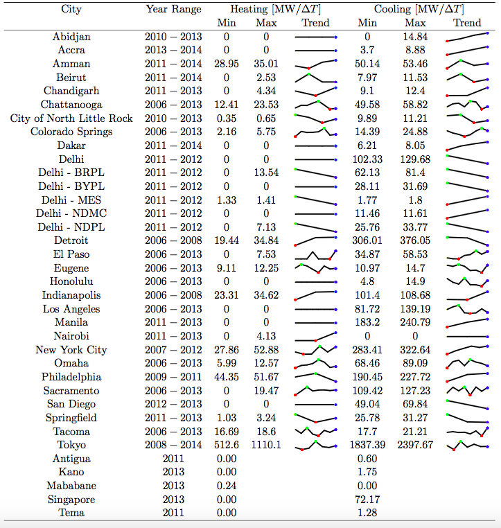

*Footnote: [1] 0-values represent beta coefficients that we feel to reject as different from zero at the 90% confidence level. [2]: maximum = green dot; minimum = red dot; latest value = blue dot.*

**Table 4:** Per-capita peak demand for electrical heating and cooling in W/($\Delta$ T x capita)

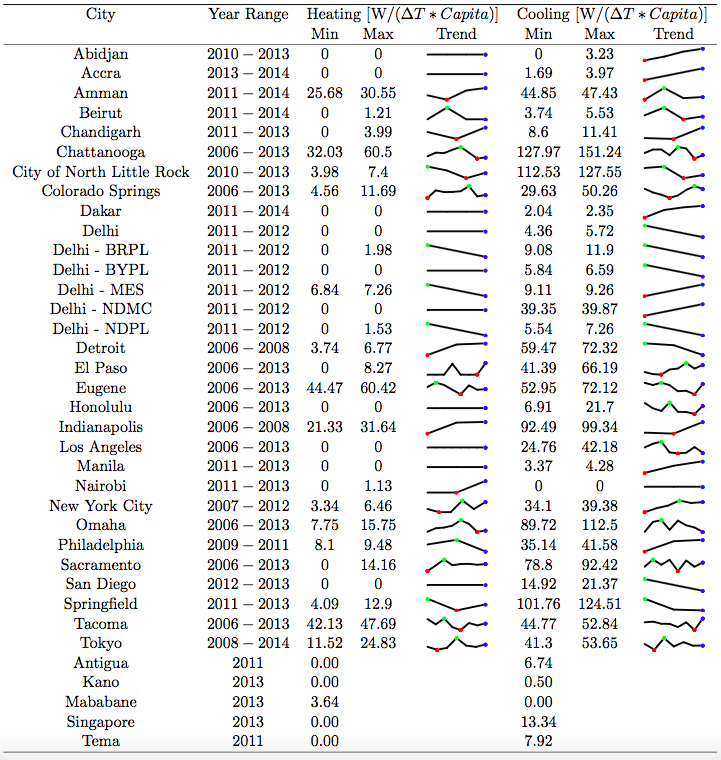

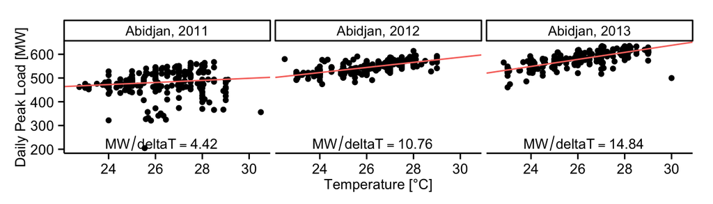

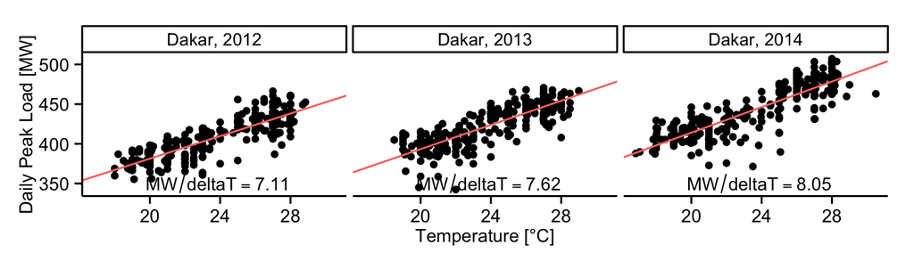

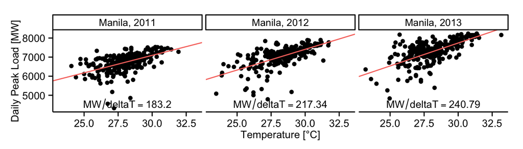

**Figure 5:** Increased penetration of cooling appliances

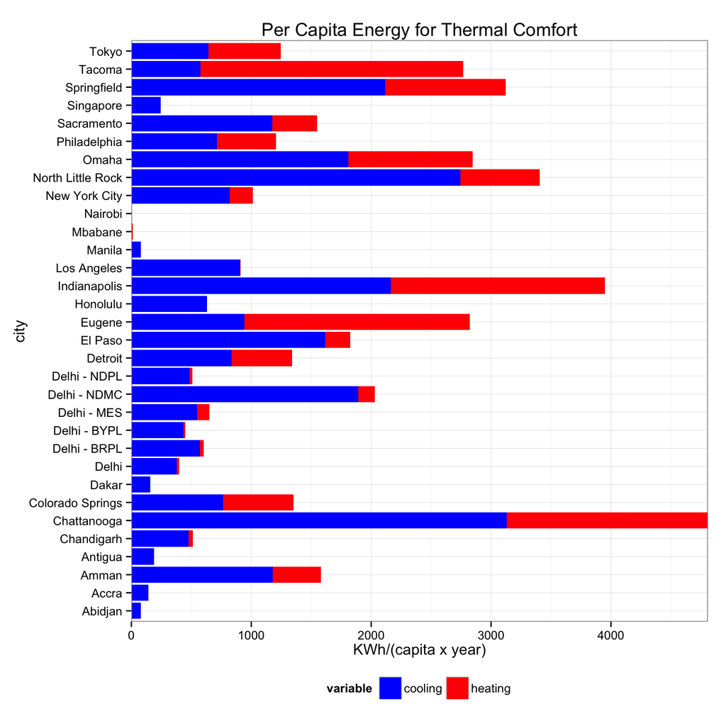

**Figure 6(a)** Per-capita integral energy consumption for heating & cooling. *Note: The following cities/years were lost as a consequence of the 350-days filter: Abidjan-2010, Accra-2013, Beirut-2011, Beirut-2012, Beirut-2013, Beirut-2014, Chandigarh-2011, Chandigarh-2013, Kano-2014, Nairobi-2011, Nairobi-2012, New York City-2007, New York City-2008, New York City-2009, Sacramento-2006, San Diego-2012, San Diego-2013, Tacoma-2006, Tema-2014.*

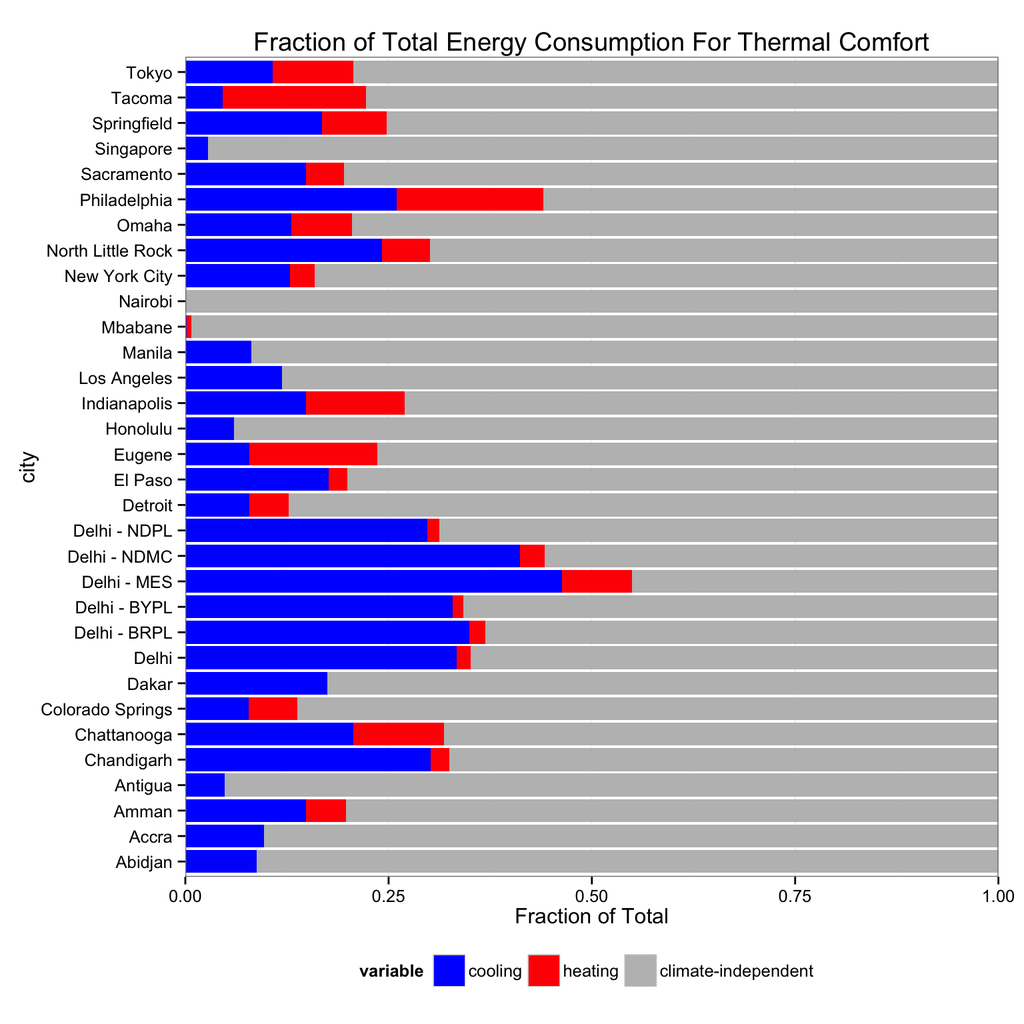

**Figure 6(b)** Normalized energy consumption for heating and cooling.

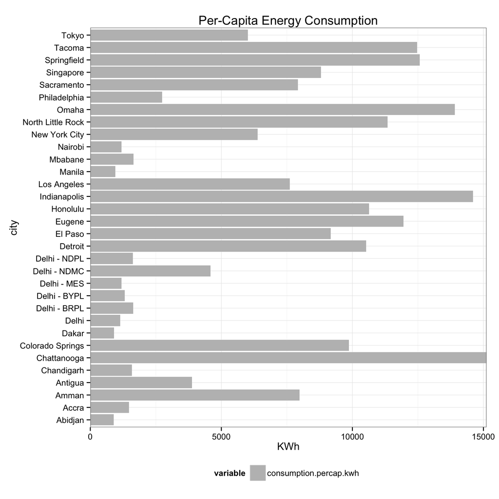

**Figure 7** Total per-capita electricity consumption

**Table 5:** Summary Table of Per-Capita Peak Demand and Integral Energy Consumption for Thermal Comfort. Cities listed in ascending order by per-capita cooling demand.

| City | Optimal HDH | Standard HDH | Heating Demand W/(°C x Capita) | Heating Energy kWh/(capita x yr) | Threshold Temperature | Optimal CDH | Standard CDH | Cooling Demand W/(°C x capita) | Cooling Energy kWh/(capita x yr) |
| --- | --- | --- | --- | --- | --- | --- | --- | --- | --- |
| Mbabane | 703 | 16342 | 3.64 | 8.48 | 13 | 67343 | 17627 | 0 | 4.09 |
| Nairobi | 297 | 15401 | 0.38 | 0.25 | 14 | 49229 | 11833 | 0 | 0 |
| Kano | - | - | 0 | - | 15 | - | - | 0.5 | - |
| Abidjan | 217 | 0 | 0 | 0 | 23 | 31781 | 59398 | 1.67 | 53 |
| Dakar | 295 | 1269 | 0 | 0 | 19 | 51995 | 42031 | 2.23 | 145.28 |
| Accra | 281 | 0 | 0 | 0 | 24 | 25264 | 58895 | 2.83 | 143.56 |
| Manila | 274 | 0 | 0 | 0 | 25 | 27714 | 72833 | 3.86 | 69.81 |
| Beirut | - | - | 0.3 | - | 22 | - | - | 4.45 | - |
| Delhi | 18158 | 15075 | 0 | 18.78 | 21 | 50783 | 57648 | 5.04 | 370.25 |
| Delhi - BYPL | 17367 | 15075 | 0 | 17.66 | 21 | 52545 | 57648 | 6.22 | 433.85 |
| Delhi - NDPL | 20765 | 15075 | 0.77 | 21.12 | 22 | 46071 | 57640 | 6.4 | 437.62 |
| Antigua | 334 | 0 | 0 | 0 | 23 | 26920 | 57246 | 6.74 | 187.98 |
| Tema | - | - | 0 | - | 24 | - | - | 7.92 | - |
| Delhi - MES | 31658 | 15075 | 7.05 | 97.31 | 25 | 28687 | 57626 | 9.19 | 516.79 |
| Chandigarh | 25318 | 19994 | 2.12 | 36.06 | 20 | 43148 | 51879 | 9.6 | 477.99 |
| Delhi - BRPL | 19673 | 15075 | 0.99 | 31.46 | 22 | 47612 | 57648 | 10.49 | 569.19 |
| Singapore | 369 | 0 | 0 | 0 | 25 | 26849 | 70280 | 13.34 | 246.35 |
| Honolulu | 492 | 267 | 0 | 0 | 21 | 37868 | 43890 | 13.8 | 661.64 |
| San Diego | - | - | 0 | - | 12 | - | - | 18.15 | - |
| Los Angeles | 4909 | 29381 | 0 | 10.06 | 12 | 58907 | 11077 | 31.33 | 875.91 |
| New York City | 44228 | 70584 | 4.61 | 205.06 | 15 | 27387 | 11342 | 37.23 | 861.06 |
| Philadelphia | 81540 | 69563 | 8.84 | 532.89 | 22 | 10334 | 15696 | 39.17 | 708.44 |
| Delhi - NDMC | 21501 | 15075 | 0 | 93.48 | 22 | 44208 | 57648 | 39.61 | 1578.51 |
| Colorado Springs | 76729 | 95634 | 7.76 | 497.02 | 17 | 15247 | 8922 | 40.39 | 627.51 |
| Amman | 26398 | 37056 | 28.3 | 469.68 | 18 | 32198 | 22059 | 45.72 | 1256.62 |
| Tokyo | 38576 | 46980 | 16.18 | 569.83 | 18 | 24925 | 18409 | 46.81 | 717.92 |
| Tacoma | 45238 | 89358 | 45.09 | 2112.89 | 14 | 11747 | 2813 | 49.2 | 537.19 |
| El Paso | 34754 | 39188 | 2 | 133.8 | 19 | 36697 | 31530 | 52.56 | 1481.38 |
| Eugene | 31847 | 83768 | 53.29 | 1673.64 | 12 | 21269 | 5259 | 64.95 | 736.74 |
| Detroit | 81195 | 91008 | 5.66 | 446.63 | 18 | 13381 | 9670 | 67.36 | 894.36 |
| Sacramento | 55805 | 53138 | 7.75 | 321.38 | 20 | 13601 | 14437 | 87.21 | 1099.84 |
| Indianapolis | 56101 | 80296 | 28.02 | 1535.11 | 16 | 27676 | 12658 | 94.96 | 2193.52 |
| Omaha | 89717 | 93035 | 10.76 | 940.55 | 19 | 15645 | 14304 | 100.9 | 1880.23 |
| Springfield | 69646 | 70495 | 8.54 | 833.26 | 20 | 18281 | 17841 | 109.9 | 2333.51 |
| North Little Rock | 58320 | 48744 | 5.8 | 528.6 | 22 | 20233 | 27351 | 120.6 | 2927.04 |
| Chattanooga | 44455 | 52451 | 44.63 | 1618.04 | 18 | 27527 | 20691 | 141 | 3782.51 |

*Footnote: Optimal HDH/CDH are calculated from the derived city-specific Threshold Temperature. Standard HDH/CDH are calculated assuming a 20°C baseline Threshold Temperature*

**Table 6:** Urban Peak Load Analysis. Cities listed in ascending order by contribution of cooling to overall peak demand.

| City | Date | Hour | Temperature [°C] | Peak Demand [MW] | Peak Cooling Demand [MW] | % Demand for Cooling |
| --- | --- | --- | --- | --- | --- | --- |
| Mbabane | 2013-07-12 | 10 | 19 | 21.83 | 0 | 0 |
| Nairobi | 2013-11-14 | 20 | 27 | 724.4 | 0 | 0 |
| Tacoma | 2013-03-01 | 19 | 14.2 | 640 | 4.24 | 0.66 |
| Singapore | 2013-06-25 | 14 | 27 | 6804 | 144.3 | 2.12 |
| Tema | 2014-02-14 | 20 | 28 | 208.8 | 5.1 | 2.44 |
| Antigua | 2011-06-29 | 12 | 29 | 50.75 | 3.38 | 6.66 |
| Accra | 2014-01-16 | 21 | 28.5 | 541.4 | 39.97 | 7.38 |
| Kano | 2014-08-29 | 2 | 27.14 | 267 | 21.86 | 8.19 |
| Honolulu | 2013-10-28 | 20 | 29.4 | 1162 | 111.8 | 9.62 |
| Beirut | 2014-07-24 | 1 | 26 | 553.2 | 59.4 | 10.74 |
| Abidjan | 2013-03-12 | 21 | 28.2 | 635.3 | 77.17 | 12.15 |
| San Diego | 2013-08-30 | 15 | 25.6 | 4604 | 711 | 15.44 |
| Dakar | 2014-10-28 | 22 | 28 | 507.2 | 80.49 | 15.87 |
| Manila | 2013-05-07 | 13 | 31.37 | 8237 | 1509 | 18.32 |
| Delhi - NDPL | 2012-06-22 | 16 | 36.5 | 1481 | 349.1 | 23.57 |
| Delhi | 2012-07-05 | 15 | 34 | 5360 | 1290 | 24.07 |
| Chandigarh | 2013-06-06 | 14 | 28.27 | 352 | 87.49 | 24.86 |
| Delhi - BYPL | 2012-07-05 | 15 | 34 | 1269 | 359.8 | 28.36 |
| Delhi - NDMC | 2012-07-04 | 15 | 32 | 351.6 | 110.1 | 31.32 |
| Los Angeles | 2013-09-05 | 17 | 32.2 | 5862 | 2049 | 34.96 |
| Delhi - MES | 2012-07-04 | 13 | 34 | 44.61 | 15.89 | 35.62 |
| Detroit | 2008-07-16 | 16 | 30 | 11011 | 3957 | 35.93 |
| Colorado Springs | 2013-06-27 | 16 | 33.3 | 883 | 334.4 | 37.87 |
| Delhi - BRPL | 2012-07-02 | 16 | 36.5 | 2311 | 920.7 | 39.85 |
| Tokyo | 2014-08-05 | 14 | 29.4 | 49800 | 22552 | 45.28 |
| New York City | 2012-07-18 | 14 | 30.1 | 11112 | 5043 | 45.38 |
| Omaha | 2013-08-29 | 17 | 33.9 | 2351 | 1070 | 45.52 |
| Amman | 2014-08-26 | 15 | 31 | 1507 | 697 | 46.27 |
| El Paso | 2013-06-27 | 16 | 33.3 | 1750 | 822.7 | 47.01 |
| Springfield | 2013-06-27 | 16 | 32.8 | 721 | 339.2 | 47.05 |
| Sacramento | 2013-07-03 | 18 | 33.3 | 3014 | 1493 | 49.54 |
| Eugene | 2013-07-01 | 17 | 25.6 | 366 | 190.9 | 52.15 |
| Indianapolis | 2008-09-02 | 15 | 29.2 | 2858 | 1494 | 52.29 |
| North Little Rock | 2013-06-27 | 17 | 35 | 249 | 139 | 55.84 |
| Eugene | 2013-07-01 | 18 | 26.95 | 366 | 210.5 | 57.5 |
| Chattanooga | 2013-07-17 | 17 | 32.8 | 1115 | 658.4 | 59.05 |
| Indianapolis | 2008-09-02 | 16 | 31.7 | 2858 | 1766 | 61.79 |
| Philadelphia | 2011-07-22 | 17 | 37.8 | 4704 | 3507 | 74.55 |

## Acknowledgements

We would like to acknowledge the following organizations for their cooperation: Thika Power, Autorite Nationale de Regulation du Secteur d’Electricite, Kenya Power & Light, Philippine Electricity Market Corporation, Ghana Grid Company, Senelec, Electricite du Liban, National Electric Power Company, Tokyo Electric Power Company and Swaziland Electricity Company, Strategy& (formerly Booz&Company).

## Appendix

### Supplementary material

All data and analysis used in this study are available online at https://github.com/ecohen4/energy. We encourage readers to fork the repository and contribute to the open-source research community via pull requests.

### Delhi DISCOM to District Mapping

| DISCOM | Districts |
| --- | --- |
| NDMC | New Delhi |
| MES | Military |
| BRPL | W-SW-S |
| BYPL | NE-E-Central |
| NDPL | NW-N |

## References

[1] Segal M., Shafer H., Mandel M.. Alpert P., & Balmor V. (1992). Climatic-related evaluations of the summer peak-hours’ electrical load in Israel. *Journal of Applied Meteorology*, 31, 1492-1498.  
[2] Christian Crowley., & Frederick L. Joutz. (2003). Hourly electricity loads: temperature elasticities and climate change. 23rd US Association of Energy Economics North American Conference.  
[3] Marcus J. Thatcher. (2007). Modeling changes to electricity demand load duration curves as a consequence of predicted climate change for Australia. *Energy*, 32, 1647-1659.  
[4] Bose, R.K., & M. Shukla. (1999). Elasticities of electricity demand in India. *Energy Policy*, 27(3), 137-146.  
[5] Tiwari, P. (2000). Architectural, demographic, and economic causes of electricity consumption in Bombay. *Journal of Policy Modelling* 22(1), 81–98.  
[6] Shonali Pachauri. (2004). An analysis of cross-sectional variations in total household energy requirements in India using micro survey data. *Energy Policy*, 32, 1723-1735. [7] The World Bank. (2008). Residential Consumption of Electricity in India: Documentation of Data and Methodology.  
[8] Pachauri, S. & Spreng, D. (2004) Energy Use and Energy Access in Relation to Poverty. *Economic and Political Weekly*, Vol. 39, No. 3 (Jan. 17-23, 2004), pp. 271-278  
[9] Gupta, (2012). Global Warming and Electricity Demand in the Rapidly Growing City of Delhi: A Semi-Parametric Coefficient Approach, *Energy*  
[10] Gupta, (2014). The Effect Of Development on the Climate Sensitivity of Electricity in India, Discussion Papers in Economics, Indian Statistical Institute, Delhi, India  
[11] David J. Sailor., J, Ricardo Munoz. (1997). Sensitivity of electricity and natural gas consumption to climate in the USA—methodology and results for eight states. *Energy*, 22(10), 987-998.  
[12] Joshua D. Rhodes., Wesley J. Cole., Charles R. Upshaw., Thomas F. Edgar., & Michael E. Webber. Clustering analysis of residential electricity demand profiles. *Applied Energy*, 135, 461-471.  
[13] Heck, S. & Rogers, M. (2014). Resource Revolution (1st Edition). New York: Houghton Mifflin Harcourt  
[14] Smit,Remes, Manyika, Roxburgh, Restrepo (2011). Urban world: Mapping the economic power of cities. McKinsey Global Institute.  
[15] IEA World Energy Outlook 2014 Fact sheet  
[16] Austin Energy. (2006). Residential Electricity burden: an investigation of American community survey data.  
[17] David J. Sailor., J, Ricardo Munoz. (1997). Sensitivity of electricity and natural gas consumption to climate in the USA—methodology and results for eight states. Energy, 22(10), 987-998.  
[18] Energy Information Administration. Electricity Power Monthly. http://www.eia.gov/ electricity/monthly/index.cfm  
[19] Huang, Y. J., Ritschard, R., Bull, J., Chang, L. (1986), Climatic indicators for estimating residential heating and cooling loads. Lawrence Berkeley Laboratory, Report LBL-21 I01, Berkeley, CA.  
[20] Joshua D. Rhodes., Wesley J. Cole., Charles R. Upshaw., Thomas F. Edgar., & Michael E. Webber. Clustering analysis of residential electricity demand profiles. *Applied Energy*, 135, 461-471.  
[21] Li, X., Sailor, D.J.,(1995). Electricity use sensitivity to climate and climate change. *World Resource*, 7(3), 334-346.  
[22] Massimo Filippini., & Shonali Pachauri. (2004). Elasticities of electricity demand in urban Indian households. *Energy Policy*, 32, 429-436.  
[23] Sailor DJ. (2001). Relating residential and commercial sector electricity loads to climate —evaluating state level sensitivities and vulnerabilities. *Energy*, 26, 645-657.  
[24] Scott, M.J., Wrech, L.E., Hadley, D.L. (1994). Effects of Climate Change on Commercial Building Energy Demand. *Energy Sources*, 16, 317-332.  
[25] S. Mirasgedis., Y. Sarafidis., E. Georgopoulou., D.P. Lalas., M. Moschovits., F. Karagiannis., D. Papakonstantinou. (2006). Models for mid-term electricity demand forecasting incorporating weather influences. *Energy*, 31: 208–227.  
[26] U.S. Census Bureau. (1995-present). American Community Survey. http://www.census.gov/acs/  
[27] U.S. Census Bureau. Working at home is on the rise. http://www.census.gov/newsroom/releases/pdf/home_based_workers_us_infographic.pdf  
[28] Commoner, Barry. “The Environmental Cost of Economic Growth.” in Population, Resources and the Environment. Washington, DC: Government Printing Office Pp. 339-63, 1972  
[29] Edmonds, J., M. Wise, H. Pitcher, R. Richels, T. Wigley, and C. MacCracken. (1997) “An Integrated Assessment of Climate Change and the Accelerated Introduction of Advanced Energy Technologies”, Mitigation and Adaptation Strategies for Global Change, 1, pp. 311-39.  
[30] IEA. FAQ. Available online at http://www.iea.org/aboutus/faqs/energyefficiency/. Accessed May 05 2015.  
[31] Runming Yao, Baizhan Li, Koen Steemers, Energy policy and standard for built environment in China, Renewable Energy, Volume 30, Issue 13, October 2005, Pages 1973-1988, ISSN 0960-1481, http://dx.doi.org/10.1016/j.renene.2005.01.013.  
(http://www.sciencedirect.com/science/article/pii/S0960148105000376) [32] Xu P, Huang J, Shen P, Ma X, Gao X, Xu Q, Xiang Y. Commercial building energy use in six cities in Southern China. Energy Policy 2013, 53:76–89. doi:10.1016/j.enpol.2012.10.002.  
[33] DES (Directorate of Economics and Statistics). 2009. Direc- torate of Economics and Statistics. www.delhi.gov.in/wps/wcm/ connect/DOIT_DES/des/home/. Accessed March 2011.  
[34] Bas J. van Ruijven, Detlef P. van Vuuren, Bert J.M. de Vries, Morna Isaac, Jeroen P. van der Sluijs, Paul L. Lucas, P. Balachandra. (2011). Model projections for household energy use in India. *Energy Policy* 39 (2011): 7747-7761.  
[35] Chaturvedi et. al. (2011)